# Lab3

Frank

2023-03-01

Clearing the environment.

```r
rm(list = ls())
```

Loading library (package) tidyverse. It loads the ggplot2 library used to generate the plots as well as other libraries.

```r
library(tidyverse)
```

Loading the data file as a data frame.

```r
consumptionNoOil <- read.csv("consumptionNoOil.csv", header = T, stringsAsFactors = T)
summary(consumptionNoOil)
```

```
##       Year           MTOE           EstMTOE              Source
##  Min.   :1990   Min.   :  2.00   Min.   :  1.90   coal      :11
##  1st Qu.:2000   1st Qu.: 11.90   1st Qu.: 11.10   gas       :11
##  Median :2012   Median : 21.70   Median : 21.70   renewables:11
##  Mean   :2012   Mean   : 44.03   Mean   : 43.77
##  3rd Qu.:2025   3rd Qu.: 62.80   3rd Qu.: 59.20
##  Max.   :2035   Max.   :192.10   Max.   :192.10
```

```r
head(consumptionNoOil, 20)
```

```
##    Year  MTOE EstMTOE Source
## 1  1990   2.0     1.9    gas
## 2  1995   3.3     3.0    gas
## 3  2000   4.2     4.3    gas
## 4  2005  11.9    11.1    gas
## 5  2010  32.2    31.7    gas
## 6  2012  41.9    45.7    gas
## 7  2015  56.9    56.6    gas
## 8  2020  73.5    68.3    gas
## 9  2025 105.6   105.6    gas
## 10 2030 146.0   146.0    gas
## 11 2035 192.1   192.1    gas
## 12 1990  17.2    18.4   coal
## 13 1995  14.3    14.4   coal
## 14 2000  10.8    10.8   coal
## 15 2005  11.2    11.0   coal
## 16 2010  12.0    11.9   coal
## 17 2012  14.6    13.8   coal
## 18 2015  14.8    14.7   coal
## 19 2020  18.0    19.1   coal
## 20 2025  21.7    21.7   coal
```

```r
consumptionNoOil <- read.csv("consumptionNoOil.csv")
consumptionNoOil <- consumptionNoOil |> mutate(across(where(is.character),as_factor))
summary(consumptionNoOil)
```

```
##       Year           MTOE           EstMTOE              Source
##  Min.   :1990   Min.   :  2.00   Min.   :  1.90   gas       :11
##  1st Qu.:2000   1st Qu.: 11.90   1st Qu.: 11.10   coal      :11
##  Median :2012   Median : 21.70   Median : 21.70   renewables:11
##  Mean   :2012   Mean   : 44.03   Mean   : 43.77
##  3rd Qu.:2025   3rd Qu.: 62.80   3rd Qu.: 59.20
##  Max.   :2035   Max.   :192.10   Max.   :192.10
```

```r
head(consumptionNoOil, 20)
```

```
##    Year  MTOE EstMTOE Source
## 1  1990   2.0     1.9    gas
## 2  1995   3.3     3.0    gas
## 3  2000   4.2     4.3    gas
## 4  2005  11.9    11.1    gas
## 5  2010  32.2    31.7    gas
## 6  2012  41.9    45.7    gas
## 7  2015  56.9    56.6    gas
## 8  2020  73.5    68.3    gas
## 9  2025 105.6   105.6    gas
## 10 2030 146.0   146.0    gas
## 11 2035 192.1   192.1    gas
## 12 1990  17.2    18.4   coal
## 13 1995  14.3    14.4   coal
## 14 2000  10.8    10.8   coal
## 15 2005  11.2    11.0   coal
## 16 2010  12.0    11.9   coal
## 17 2012  14.6    13.8   coal
## 18 2015  14.8    14.7   coal
## 19 2020  18.0    19.1   coal
## 20 2025  21.7    21.7   coal
```

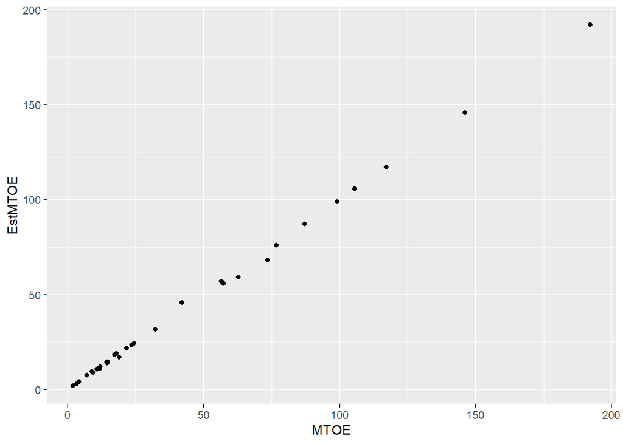

```r
p <- ggplot(data = consumptionNoOil, aes(x=MTOE, y=EstMTOE))
p <- p + geom_point()
p
```

Adding some colour - green points.

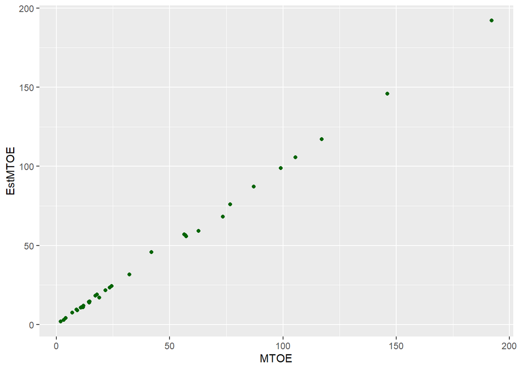

```r
p <- ggplot(data= consumptionNoOil, aes(x=MTOE,y=EstMTOE))
p <- p + geom_point(colour="darkgreen")
p
```

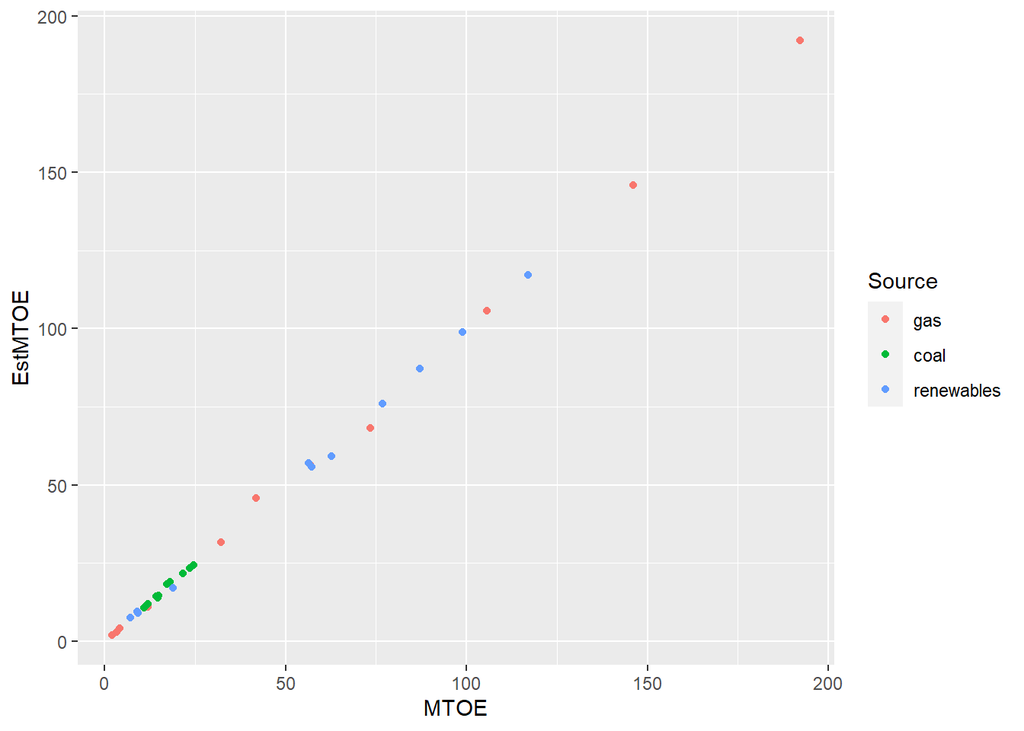

```r
p <- ggplot(consumptionNoOil, aes(MTOE, EstMTOE, colour=Source))
p <- p + geom_point()
p
```

In the above plot it is easy to see that coal-related points generally have low MTOE and EstMTOE values when compared to gas and renewables data points.

Now we try a different point shape depending on the Source of energy value.

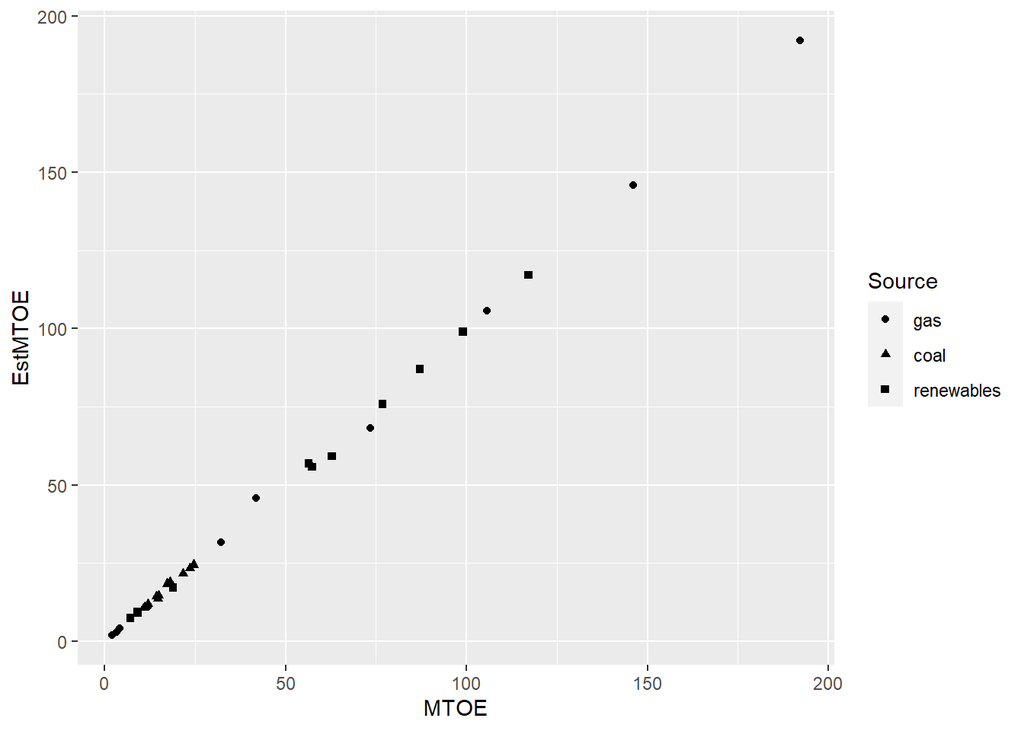

```r
p <- ggplot(consumptionNoOil, aes(MTOE, EstMTOE, shape=Source))
p <- p + geom_point()
p
```

We can combine shape and colour to illustrate the source of energy.

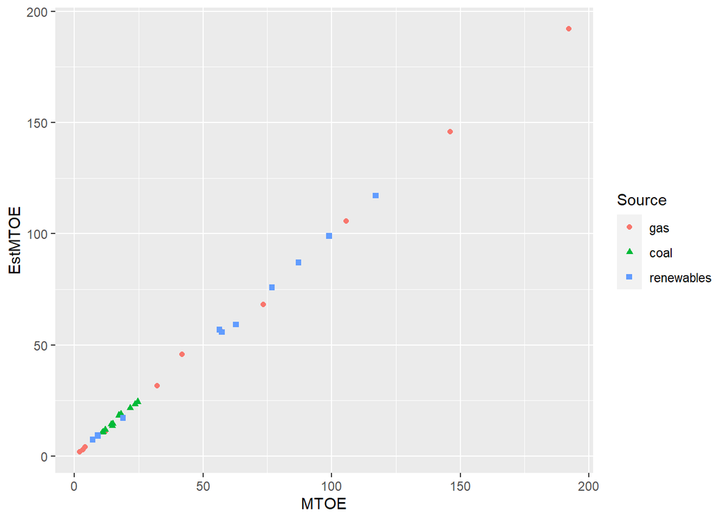

```r
p <- ggplot(consumptionNoOil, aes(MTOE, EstMTOE, colour = Source, shape=Source))
p <- p + geom_point()
p
```

Using a line. This is clearly **not a good idea**, but it illustrates why there is a need to separate the data according to the value of the Source of energy column.

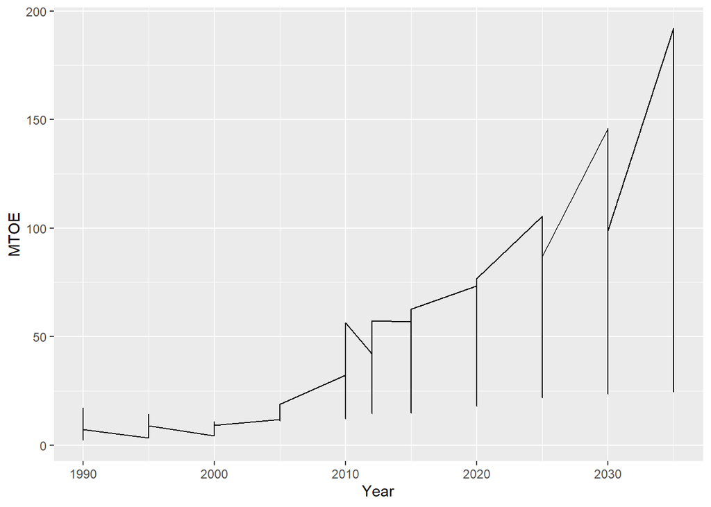

```r
p <- ggplot(consumptionNoOil, aes(Year, MTOE))
p <- p + geom_line()
p
```

More appropriate use of lines, one line per Source value.

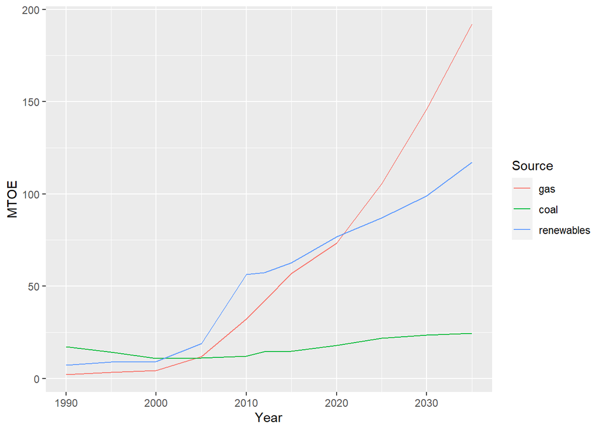

```r
p <- ggplot(consumptionNoOil, aes(Year, MTOE, colour=Source))
p <- p + geom_line()
p
```

An alternative is to group points by Source value. We get 3 lines, each representing a different source value.However, which line represents which source value is not conveyed.

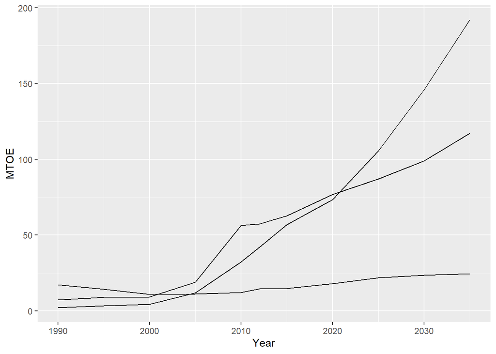

```r
p <- ggplot(consumptionNoOil, aes(Year, MTOE, group = Source))
p <- p + geom_line()
p
```

Changing the colour and thickness of the lines.

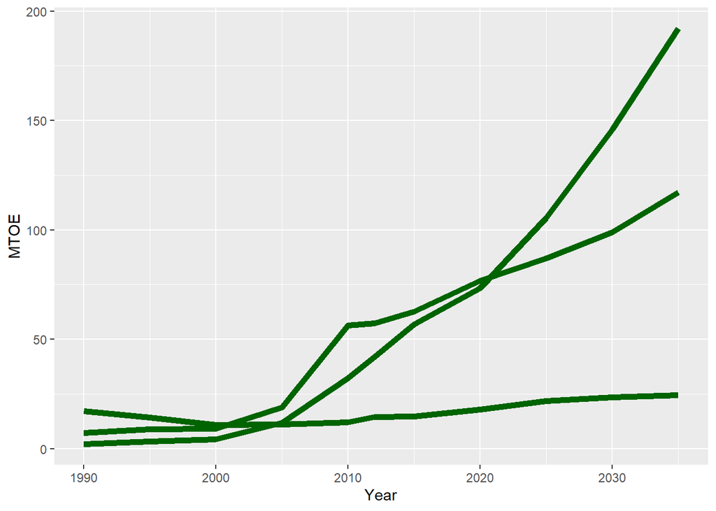

```r
p <- ggplot(consumptionNoOil, aes(Year, MTOE, group = Source))
p <- p + geom_line(size = 2, colour="darkgreen")
p
```

In the above, we can see how related data is connected via the line. Below we can see that if we just use points, that connection is not visible. We can see 3 points per year,but we do not know how they relate to previous/future years.

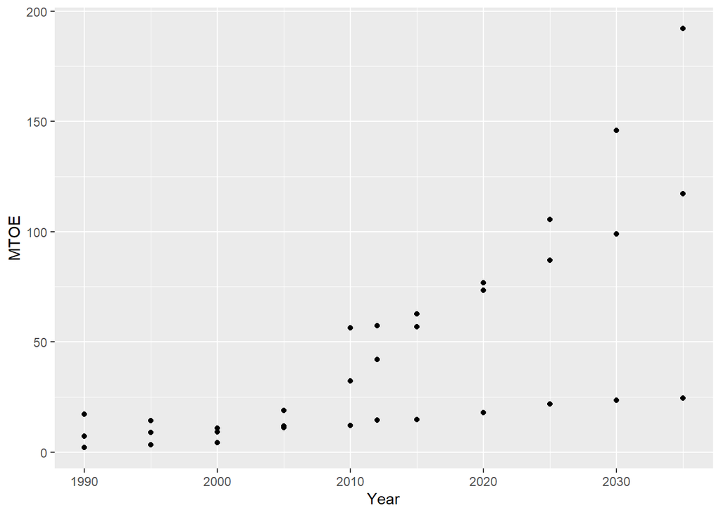

```r
p <- ggplot(consumptionNoOil, aes(Year, MTOE, group = Source))
p <- p + geom_point()
p
```

The plot below shows how several geoms can be added to a plot. In this case we have points and lines. The source value for each line is unknown.

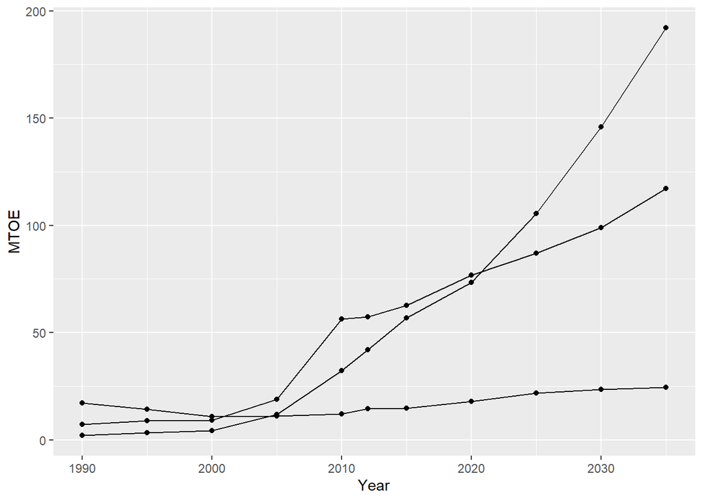

```r
p <- ggplot(consumptionNoOil, aes(Year, MTOE, group = Source))
p <- p + geom_point()
p <- p + geom_line()
p
```

Below we have a similar plot, but the points have been modified to light blue triangles with red lines.

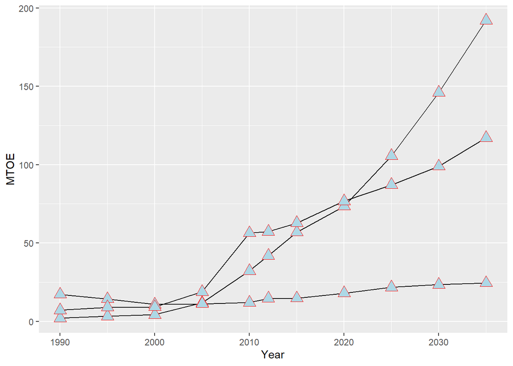

```r
p <- ggplot(consumptionNoOil, aes(Year, MTOE, group = Source))
p <- p + geom_line()
p <- p + geom_point(shape = 24, colour = "red", size = 4, fill = "lightblue")
p
```

Different groups on different layers. One smooth for all groups

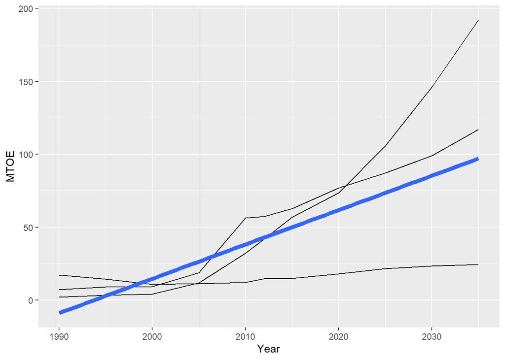

```r
p <- ggplot(consumptionNoOil, aes(Year, MTOE, group = Source))
p <- p + geom_line()
p <- p + geom_smooth(aes(group = 1), formula='y~x',method = "lm", size = 2, se = F)
p
```

Compare the above with the below, where we get one linear model per source value.

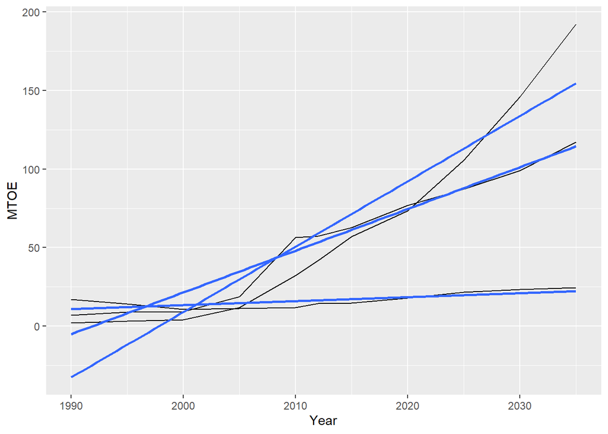

```r
p <- ggplot(consumptionNoOil, aes(Year, MTOE, group = Source))
p <- p + geom_line()
p <- p + geom_smooth(aes(group = Source), formula='y~x',method = "lm", size = 1,  se = F)
p
```

Creating a histogram with the pressureTemp dataset

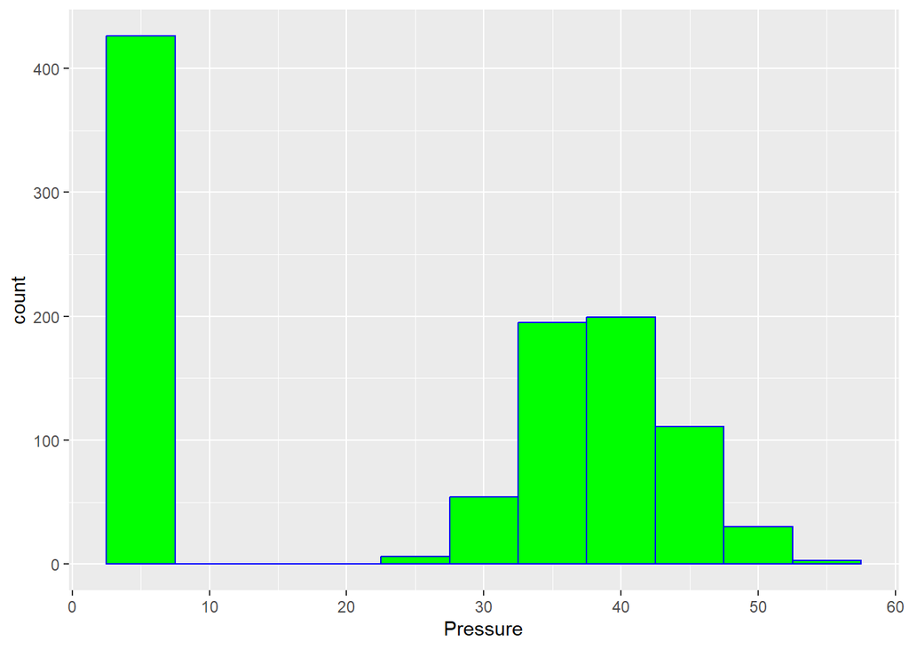

```r
pressureTemp <- read.csv("pressureTemp.csv", header=T)
p <- ggplot(pressureTemp, aes(Pressure))
p <- p + geom_histogram(colour="blue", fill="green", binwidth=5)
p
```

Loading the dataset ProvenOilReservesZerosT

```r
ProvenOilReservesZerosT <- read.csv("ProvenOilReservesZerosT.csv", header=T, stringsAsFactors=T)
```

Note that in this dataset the year column (first column) is called MTBarrels, to indicate that the unit of measure for the dataset is million ton barrels.

The dataset contains ‘-’. In R, we would normally have NA (not available) or zero.

Replacing ‘-’ by NA.

```r
ProvenOilReservesZerosT |>  mutate_all(funs(replace(., .== "-", as.double(NA))))
```

```
##    MTBarrels Azerbaijan Denmark Italy Kazakhstan Norway Romania
## 1       1980       <NA>     0.4   0.4       <NA>    4.0     1.1
## 2       1981       <NA>     0.4   0.4       <NA>    4.0     1.0
## 3       1982       <NA>     0.3   0.4       <NA>    3.8     1.0
## 4       1983       <NA>     0.3   0.4       <NA>    4.9     1.6
## 5       1984       <NA>     0.5   0.6       <NA>    5.0     1.5
## 6       1985       <NA>     0.4   0.6       <NA>    5.9     1.4
## 7       1986       <NA>     0.4   0.6       <NA>    6.5     1.4
## 8       1987       <NA>     0.4   0.7       <NA>    6.6     1.3
## 9       1988       <NA>     0.5   0.8       <NA>    8.2     1.2
## 10      1989       <NA>     0.6   0.8       <NA>    8.4     1.2
## 11      1990       <NA>     0.6   0.8       <NA>    8.6     1.5
## 12      1991       <NA>     0.6   0.8       <NA>    8.8     1.5
## 13      1992       <NA>     0.7   0.6       <NA>    9.7     1.2
## 14      1993       <NA>     0.7   0.6       <NA>    9.6     1.0
```

[output cut: 87 more lines]

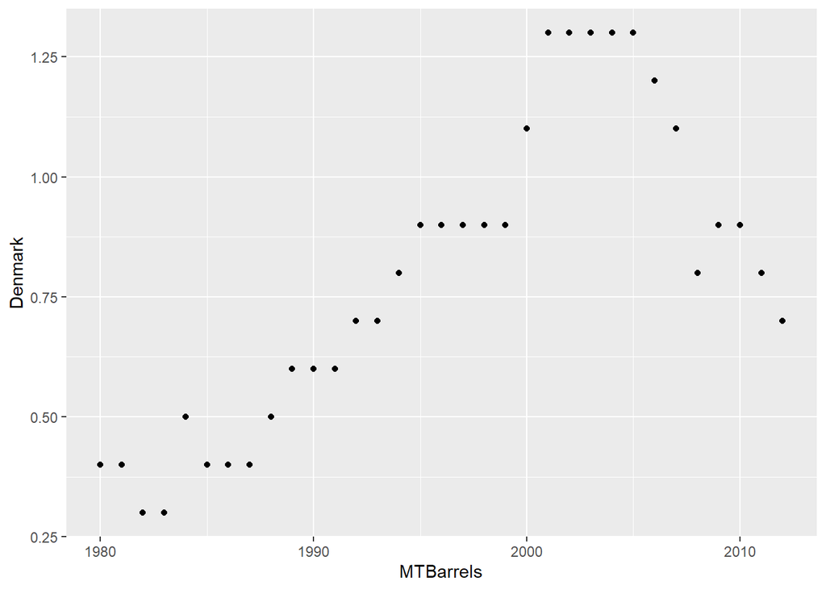

```r
p <- ggplot(ProvenOilReservesZerosT, aes(MTBarrels, Denmark))
p <- p + geom_point()
p
```

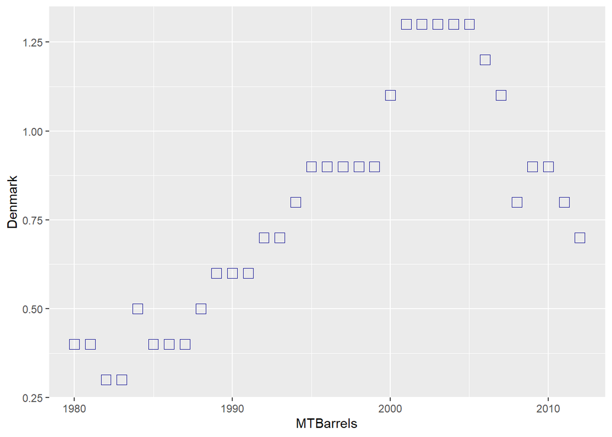

```r
p <- ggplot(ProvenOilReservesZerosT, aes(MTBarrels, Denmark))
p <- p + geom_point(shape=22, colour="darkblue", size=4)
p
```

if we want the squares filled in dark blue

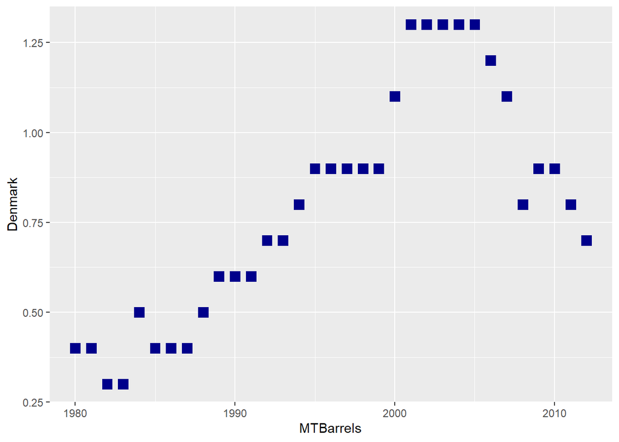

```r
p <- ggplot(ProvenOilReservesZerosT, aes(MTBarrels, Denmark))
p <- p + geom_point(shape=22, colour="darkblue", size=4, fill="darkblue")
p
```

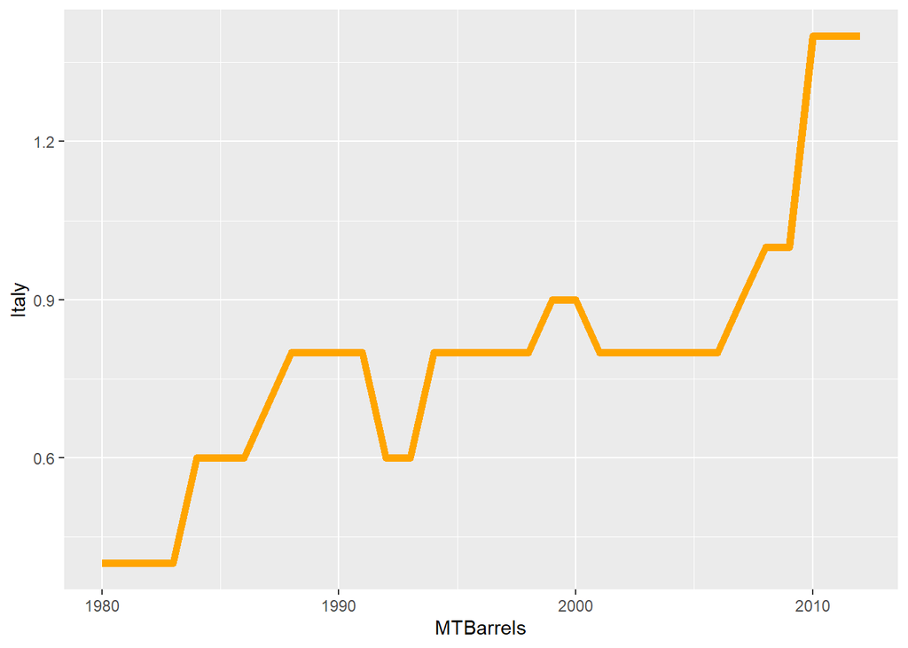

```r
p <- ggplot(ProvenOilReservesZerosT, aes(MTBarrels, Italy))
p <- p + geom_line(colour="orange", size=2)
p
```

Note that **using colour to emphasize size may not be the best option**.

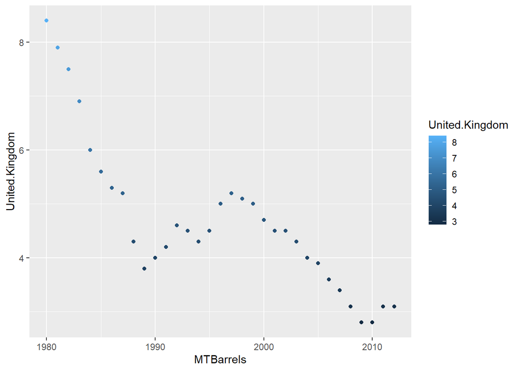

```r
p <- ggplot(ProvenOilReservesZerosT, aes(MTBarrels, United.Kingdom, colour=United.Kingdom))
p <- p + geom_point()
p
```

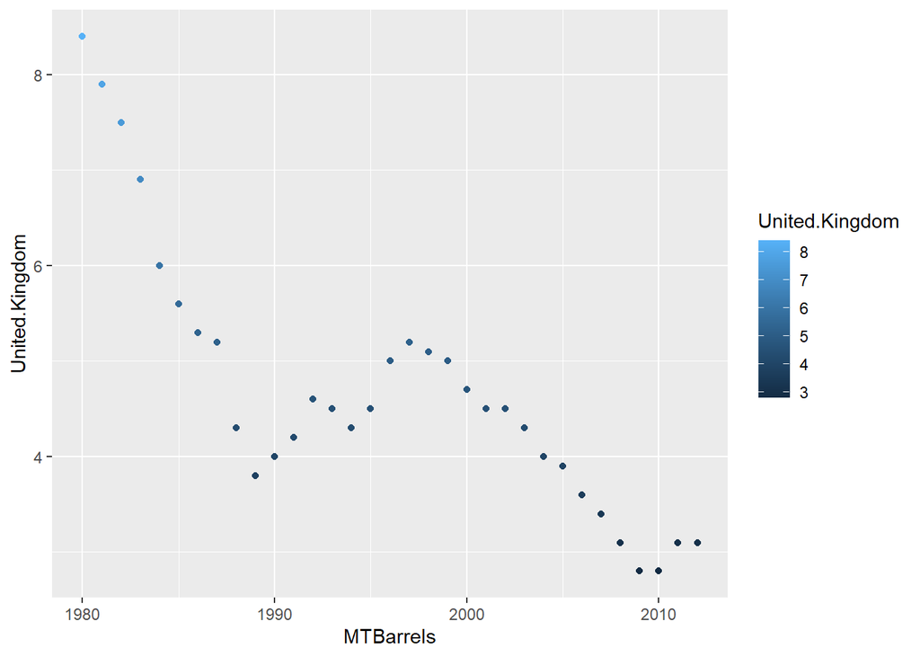

```r
p <- ggplot(ProvenOilReservesZerosT, aes(MTBarrels, United.Kingdom))
p <- p + geom_point(aes(colour=United.Kingdom))
p
```

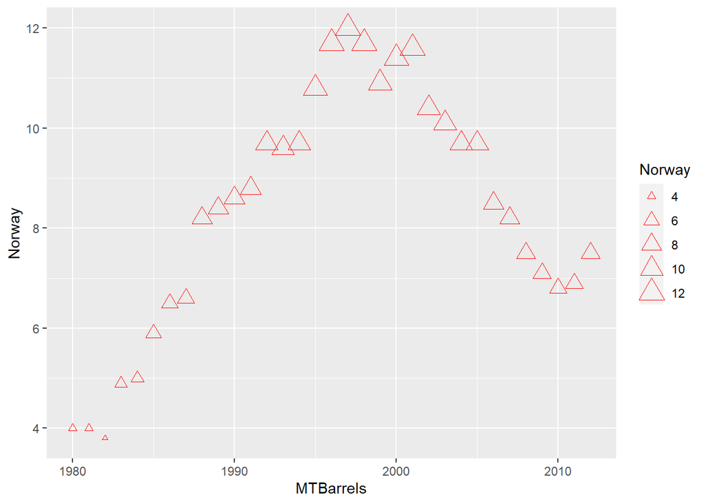

```r
p <- ggplot(ProvenOilReservesZerosT, aes(MTBarrels, Norway, size=Norway))
p <- p + geom_point(shape=24, colour="red")
p
```

Exercise 6 if we want the triangles filled in red

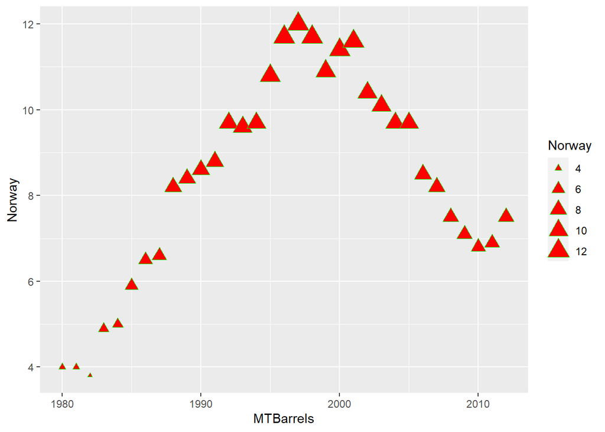

```r
p <- ggplot(ProvenOilReservesZerosT, aes(MTBarrels, Norway, size=Norway))
p <- p + geom_point(shape=24, colour="green", fill="red")
p
```

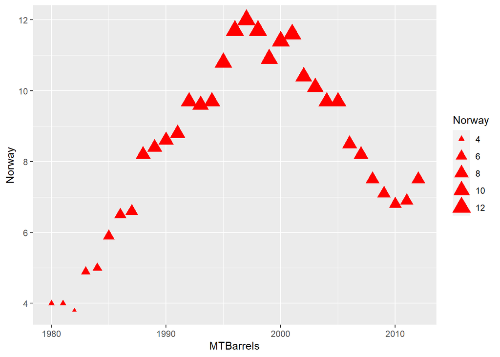

```r
p <- ggplot(ProvenOilReservesZerosT, aes(MTBarrels, Norway))
p <- p + geom_point(aes(size=Norway), shape=24, colour="red", fill="red")
p
```

Loading a second dataset

```r
ProvenOilReserveWEurope <- read.csv("ProvenOilReserveWEurope.csv", header=T, stringsAsFactors=T)
```

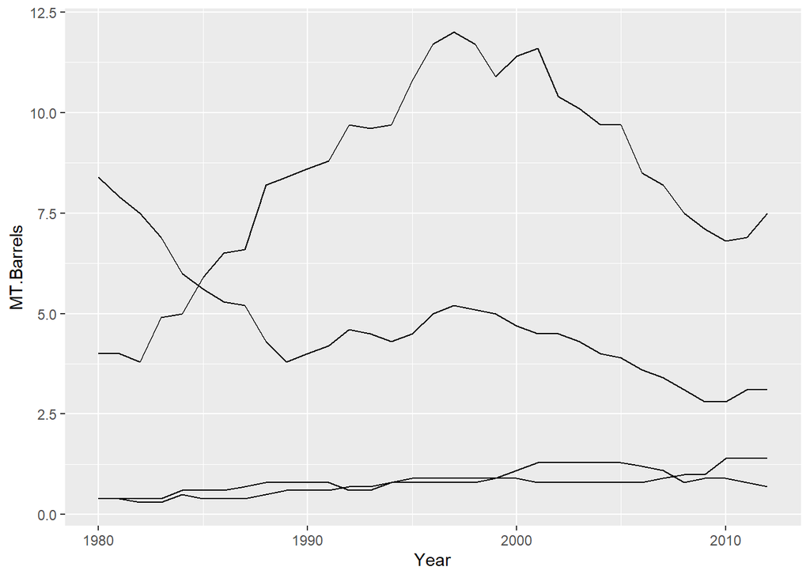

```r
p <- ggplot(ProvenOilReserveWEurope, aes(Year, MT.Barrels, group=Country))
p <- p + geom_line()
p
```

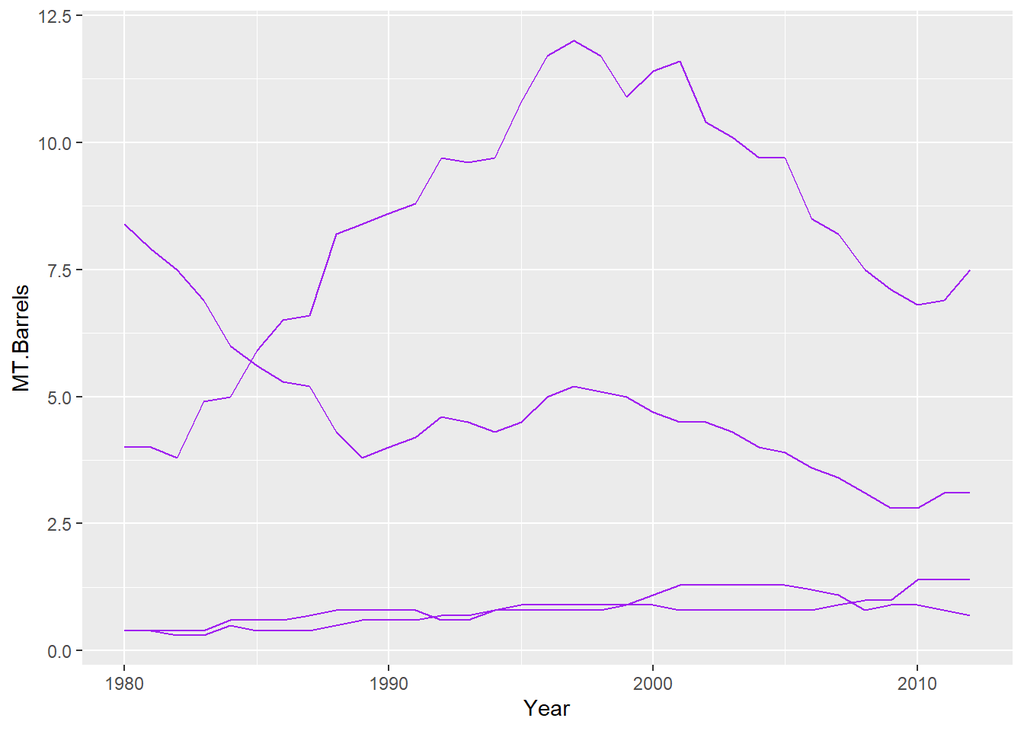

```r
p <- ggplot(ProvenOilReserveWEurope, aes(Year, MT.Barrels, group=Country))
p <- p + geom_line(colour="purple")
p
```

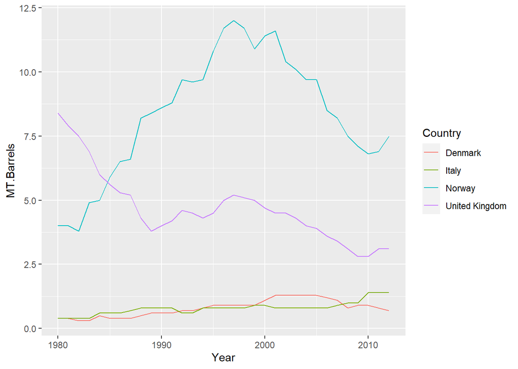

```r
p <- ggplot(ProvenOilReserveWEurope, aes(Year, MT.Barrels, group=Country, colour=Country))
p <- p + geom_line()
p
```

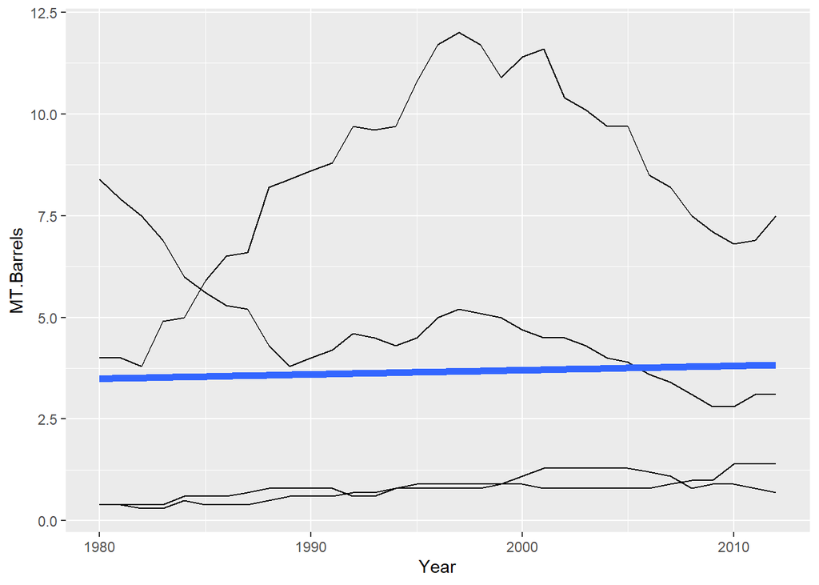

```r
p <- ggplot(ProvenOilReserveWEurope, aes(Year, MT.Barrels, group=Country))
p <- p + geom_line()
p <- p + geom_smooth(aes(group = 1), formula = y~x, method = "lm", size = 2, se = F)
p
```

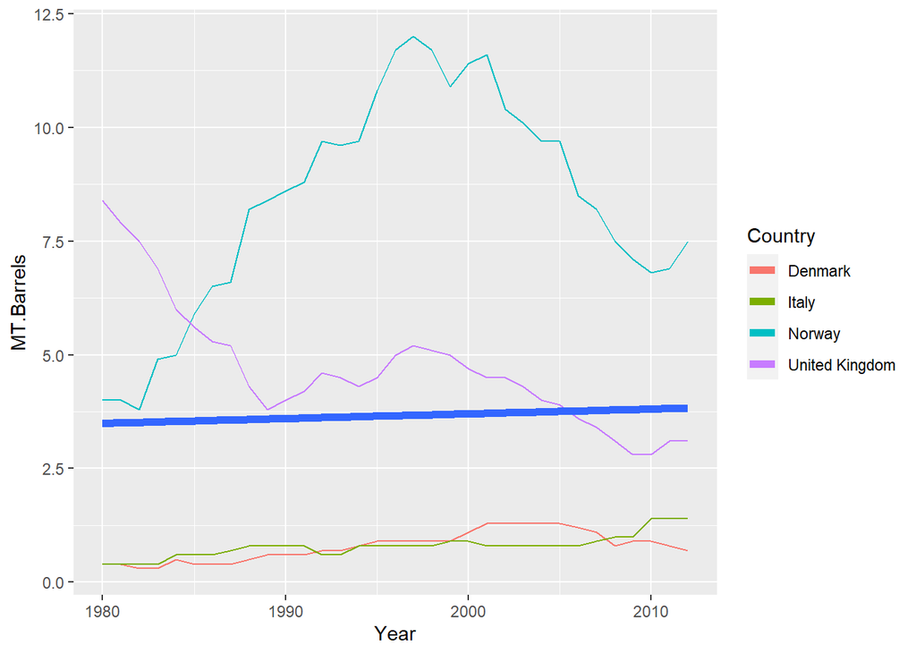

```r
p <- ggplot(ProvenOilReserveWEurope, aes(Year, MT.Barrels, group=Country, colour=Country))
p <- p + geom_line()
p <- p + geom_smooth(aes(group = 1), formula = y~x, method = "lm", size = 2, se = F)
p
```

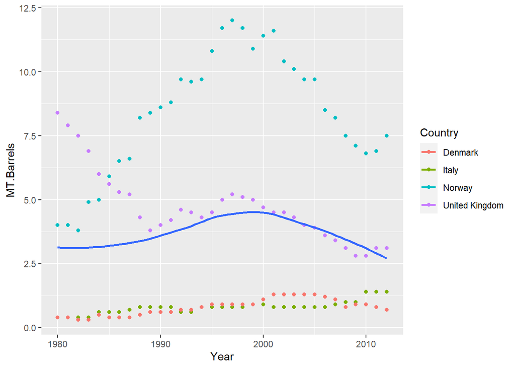

```r
p <- ggplot(ProvenOilReserveWEurope, aes(Year, MT.Barrels, group=Country,  colour=Country))
p <- p + geom_point()
p <- p + geom_smooth(aes(group = 1), formula = y~x,  method = "auto", se = F)
p
```

histogram We choose a bindwidth of 3, a red line (colour) and orange fill.

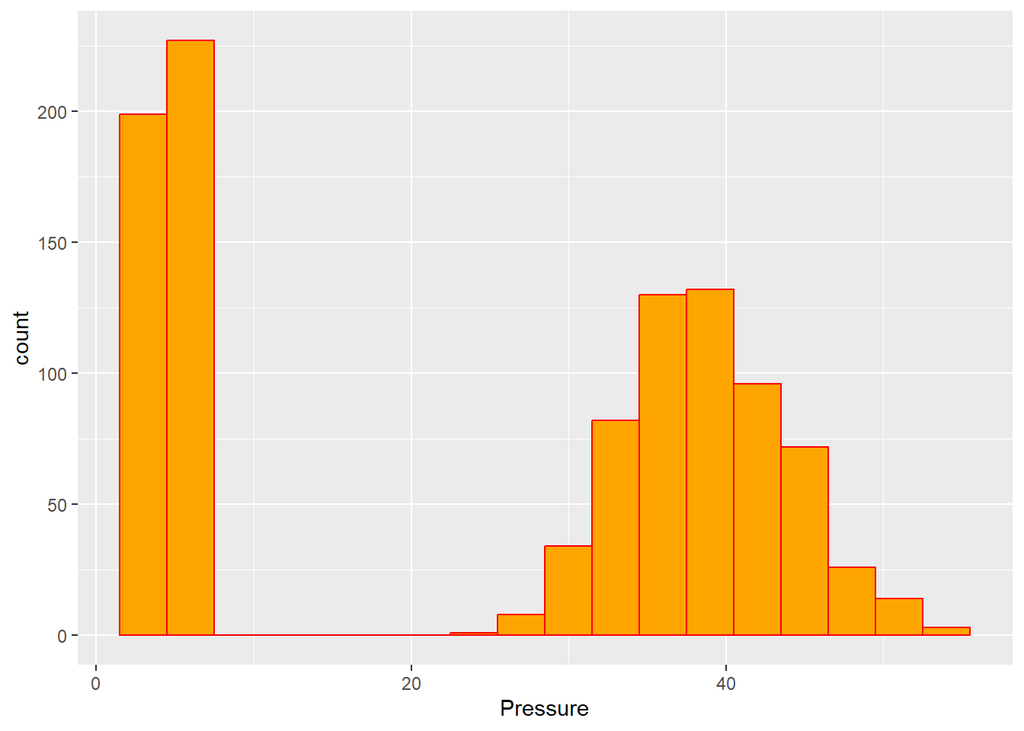

```r
pressureTemp <- read.csv("pressureTemp.csv", header=T)
p <- ggplot(pressureTemp, aes(Pressure))
p <- p + geom_histogram(colour="red", fill="orange", binwidth=3)
p
```

Note how a smaller binwidth leads to more (but narrower) “bars”.